# Name: Tanner Woods

```python
## Imports ##
import itertools
import pandas as pd
import seaborn as sns
import matplotlib.pyplot as plt
import statsmodels.api as sm
import statsmodels.stats.api as sms
import statsmodels.formula.api as smf
import statsmodels.stats.outliers_influence as smo
import statsmodels.regression.linear_model as rg
import statsmodels.stats.diagnostic as dg
import numpy as np
from BorutaShap import BorutaShap
import scipy as sp
from RegscorePy import mallow
import wooldridge as woo
import patsy as pt

from sklearn.model_selection import train_test_split
from sklearn import linear_model
from sklearn.linear_model import LinearRegression
from sklearn import metrics
from sklearn.model_selection import cross_val_score

## Global settings ##
#plt.rcParams['axes.grid'] = True
```

```python
# Import Data
df_original = woo.data('fringe')
```

```python
# Look at Data
df_original.describe()

# Subset Data to exclude redundant variables
df = df_original.iloc[:, 0:29]
df = df.drop(columns = "hrearn")

# Looking at data
df.info()

## We have no missing observations
## We have both quantitative and indicator variables
## We have at least 15-20 predictor variables
```

```
<class 'pandas.core.frame.DataFrame'>
RangeIndex: 616 entries, 0 to 615
Data columns (total 28 columns):
 #   Column    Non-Null Count  Dtype
---  ------    --------------  -----
 0   annearn   616 non-null    float64
 1   exper     616 non-null    int64
 2   age       616 non-null    int64
 3   depends   616 non-null    int64
 4   married   616 non-null    int64
 5   tenure    616 non-null    float64
 6   educ      616 non-null    int64
 7   nrtheast  616 non-null    int64
 8   nrthcen   616 non-null    int64
 9   south     616 non-null    int64
```

[output cut: 20 more lines]

# Part 1. Variable Selection

## Part 1a. Boruta

```python
# First we will subset the data to remove indicator variables
# This is because Because Boruta does not work with indicators

# Make a copy of our dataframe
df_copy = df.copy()

# Subset to remove indicator variables and separate independent from dependent variables
df_boruta_Independents = df_copy.iloc[:, [1,2,3,5,6,14,24,25,26,27]]
df_boruta_Dependents = df_copy.iloc[:, 0]
```

```
5 attributes confirmed important: ['annhrs', 'pension', 'insur', 'exper', 'vacdays']
5 attributes confirmed unimportant: ['age', 'educ', 'sicklve', 'depends', 'tenure']
0 tentative attributes remains: []
```

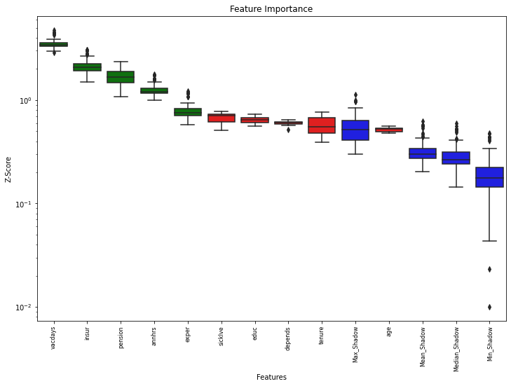

```python
# Boruta Algorithm
Feature_Selector = BorutaShap(importance_measure = 'shap', classification = False)
Feature_Selector.fit(df_boruta_Independents, df_boruta_Dependents, n_trials = 100, random_state = 0)
Feature_Selector.plot(which_features = 'all')
```

Since we have many indicator variables, this does not tell the full story. We will now try to evaluate the importance of our indicator variables to see which of them should be included in our model.

```python
## Get the base model, y and its fitted value
model = smf.ols(formula = 'annearn ~ exper + age + depends + married + tenure + educ + \
    + nrtheast + nrthcen + south + male + white + union + office + annhrs + \
        ind1 + ind2 + ind3 + ind4 + ind5 + ind6 + ind7 + ind8 + vacdays + sicklve \
            + insur + pension', data = df)
results = model.fit()
y_mallows = df['annearn']
y_mallows_pred = results.fittedvalues

# Manually Running Mallows Cp for indicator variables
mr_sub1 = smf.ols(formula = 'annearn ~ married', data = df).fit()
y_mallows_sub1 = mr_sub1.fittedvalues

mr_sub2 = smf.ols(formula = 'annearn ~ nrtheast', data = df).fit()
y_mallows_sub2 = mr_sub2.fittedvalues

mr_sub3 = smf.ols(formula = 'annearn ~ nrthcen', data = df).fit()
y_mallows_sub3 = mr_sub3.fittedvalues

mr_sub4 = smf.ols(formula = 'annearn ~ south', data = df).fit()
y_mallows_sub4 = mr_sub4.fittedvalues

mr_sub5 = smf.ols(formula = 'annearn ~ male', data = df).fit()
y_mallows_sub5 = mr_sub5.fittedvalues

mr_sub6 = smf.ols(formula = 'annearn ~ white', data = df).fit()
y_mallows_sub6 = mr_sub6.fittedvalues

mr_sub7 = smf.ols(formula = 'annearn ~ union', data = df).fit()
y_mallows_sub7 = mr_sub7.fittedvalues

mr_sub8 = smf.ols(formula = 'annearn ~ office', data = df).fit()
y_mallows_sub8 = mr_sub8.fittedvalues

mr_sub9 = smf.ols(formula = 'annearn ~ ind1', data = df).fit()
y_mallows_sub9 = mr_sub9.fittedvalues
# I tried all the industry variables and they have high cp scores

print(mallow.mallow(y_mallows, y_mallows_pred, y_mallows_sub1, 27, 2))
print(mallow.mallow(y_mallows, y_mallows_pred, y_mallows_sub2, 27, 2))
print(mallow.mallow(y_mallows, y_mallows_pred, y_mallows_sub3, 27, 2))
print(mallow.mallow(y_mallows, y_mallows_pred, y_mallows_sub4, 27, 2))
print(mallow.mallow(y_mallows, y_mallows_pred, y_mallows_sub5, 27, 2))
print(mallow.mallow(y_mallows, y_mallows_pred, y_mallows_sub6, 27, 2))
print(mallow.mallow(y_mallows, y_mallows_pred, y_mallows_sub7, 27, 2))
print(mallow.mallow(y_mallows, y_mallows_pred, y_mallows_sub8, 27, 2))
print(mallow.mallow(y_mallows, y_mallows_pred, y_mallows_sub9, 27, 2))
```

```
276.0781819463547
322.69175637038677
322.16602554435485
318.8717286094412
202.16167053450033
309.5773335767368
317.75668125672223
306.6675120684657
322.6667769337256
```

```python
# Mallows Cp from Kunz lecture 3

## Only going to include industry 1 as a proxy since all industries had a similar individual cp score
subdat = df[['annearn', 'married', 'nrtheast', 'nrthcen', 'south', 'male', 'white', 'union', 'office', 'ind1']]
# ^ includes ind1, just cut off

model_ind = smf.ols(formula = 'annearn ~ married + nrtheast + nrthcen + south + male + white + \
    union + office + ind1', data = df)
results_ind = model_ind.fit()
y_mallows = df['annearn']
y_pred = results_ind.fittedvalues

storage_cp = pd.DataFrame(columns = ["Variables", "CP"])
k = 10 # number of parameters in orginal model (includes y-intercept)

for L in range(1, len(subdat.columns[1:]) + 1):
    for subset in itertools.combinations(subdat.columns[1:], L):

        # join the strings in the data together
        formula1 = 'annearn~'+'+'.join(subset)

        # get the cp
        results = smf.ols(formula=formula1, data = df).fit()
        y_sub = results.fittedvalues
        p = len(subset)+1 # number of parameters in the subset model (includes y-intercept)

        cp = mallow.mallow(y_mallows, y_pred,y_sub, k, p)

        # add to the dataframe
        storage_cp = storage_cp.append({'Variables': subset, 'CP': cp}, ignore_index = True)
```

```python
storage_cp.sort_values(by = "CP")
```

|  | Variables | CP |
| --- | --- | --- |
| 320 | (married, male, white, union, office) | 5.97694 |
| 411 | (married, nrtheast, male, white, union, office) | 6.311646 |
| 178 | (married, male, union, office) | 6.436247 |
| 283 | (married, nrtheast, male, union, office) | 6.789186 |
| 480 | (married, nrtheast, south, male, white, union,... | 7.623399 |
| ... | ... | ... |
| 29 | (nrthcen, ind1) | 145.892063 |
| 17 | (nrtheast, nrthcen) | 145.931068 |
| 198 | (nrtheast, nrthcen, union, ind1) | 146.200589 |
| 23 | (nrtheast, ind1) | 146.326514 |
| 78 | (nrtheast, nrthcen, ind1) | 147.882874 |

511 rows × 2 columns

From this, it is clear that the industry variables are not very helpful. Instead, the best indicator variables are

- $married$
- $male$
- $white$
- $union$
- $office$

## Part 1b. Predictor Choice

Based upon the above work, we will select our preferred predictors as being the 5 quantitative variables found using Boruta and the 5 indicator variables found using Mallows $C_p$. Hence our variables are:

1. $vacdays$
2. $insur$
3. $annhrs$
4. $exper$
5. $pension$
6. $married$
7. $male$
8. $white$
9. $union$
10. $office$

```python
df_final = df[["annearn", "exper", "married", "male", "white", "union", "office", "annhrs", "vacdays", "insur", "pension"]]
# includes the 10 previously determined variables, just cut off
```

# Part 2. Descriptive Analysis

## Part 2a. Histograms, QQ Plots, Correlation Plots, etc.

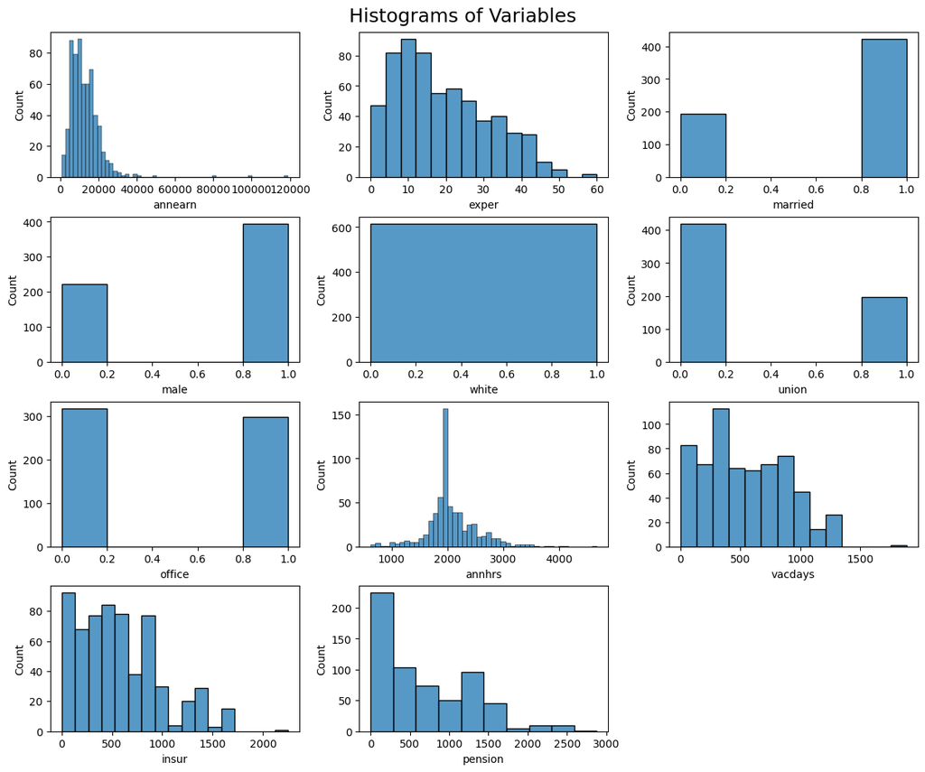

```python
# Histograms
fig, axes = plt.subplots (4, 3, figsize = (12,10), constrained_layout = True)
fig.suptitle("Histograms of Variables", fontsize = 18)
Axis_x = 0
for i in range (0, len(df_final.columns)):
    Axis_y = i // 3
    if Axis_x > 2:
            Axis_x = 0
    sns.histplot(x=df_final.iloc[:,i], bins = 'fd', kde=False, ax = axes[Axis_y, Axis_x])
    Axis_x +=1
fig.delaxes(axes[3][2])
plt.show()
```

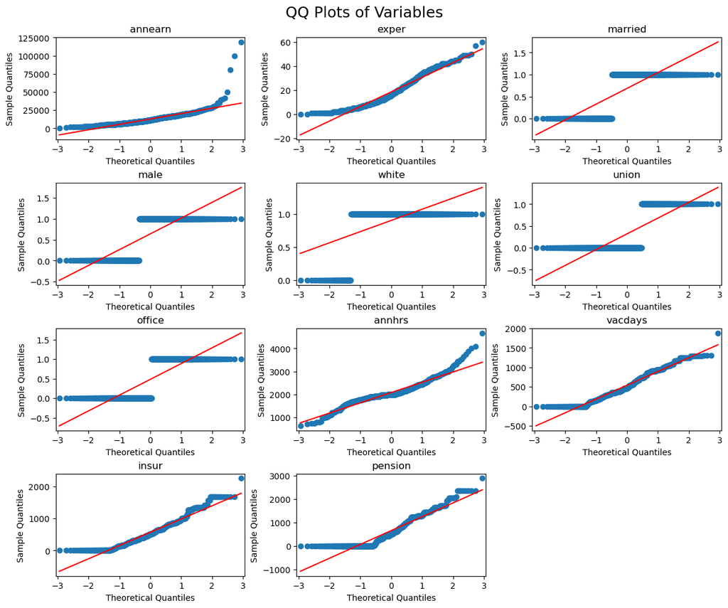

```
age
```

```python
# QQ Plots
listname = ["annearn", "exper", "married", "male", "white", "union", "office", "annhrs",
         "vacdays", "insur", "pension"]

fig, axes = plt.subplots (4, 3, figsize = (12,10), constrained_layout = True)
fig.suptitle("QQ Plots of Variables", fontsize = 18)
Axis_x = 0
for i in range (0, len(df_final.columns)):
    Axis_y = i // 3
    if Axis_x > 2:
            Axis_x = 0
    sm.qqplot(df_final.iloc[:,i], line='r', ax = axes[Axis_y, Axis_x])
    axes[Axis_y, Axis_x].set_title(df_final.columns[i])
    Axis_x +=1
fig.delaxes(axes[3][2])
plt.show()

print(df.columns[2])
```

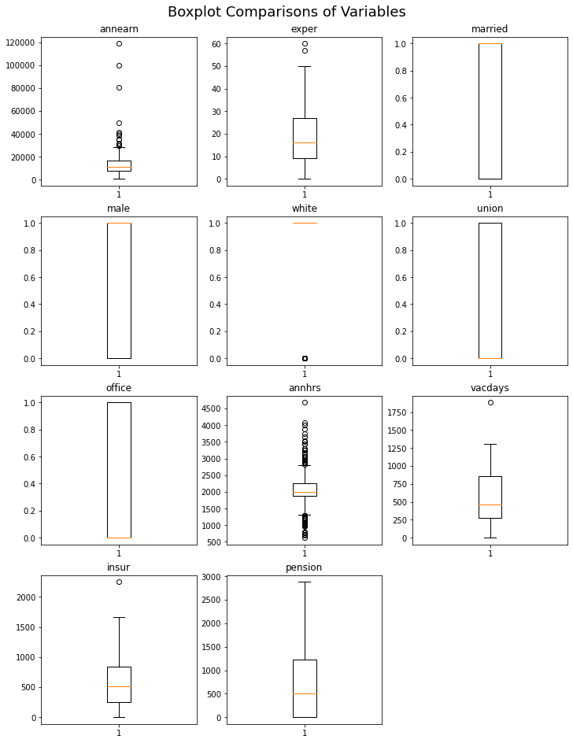

```python
# Box Plots
fig, axes = plt.subplots (4, 3, figsize = (10,13), constrained_layout = True)
fig.suptitle("Boxplot Comparisons of Variables", fontsize = 18)
Axis_x = 0
for i in range (0, len(df_final.columns)):
    Axis_y = i // 3
    if Axis_x > 2:
            Axis_x = 0
    axes[Axis_y, Axis_x].boxplot(df_final.iloc[:,i])
    axes[Axis_y, Axis_x].set_title(df_final.columns[i])
    Axis_x +=1
fig.delaxes(axes[3][2])
plt.show()
```

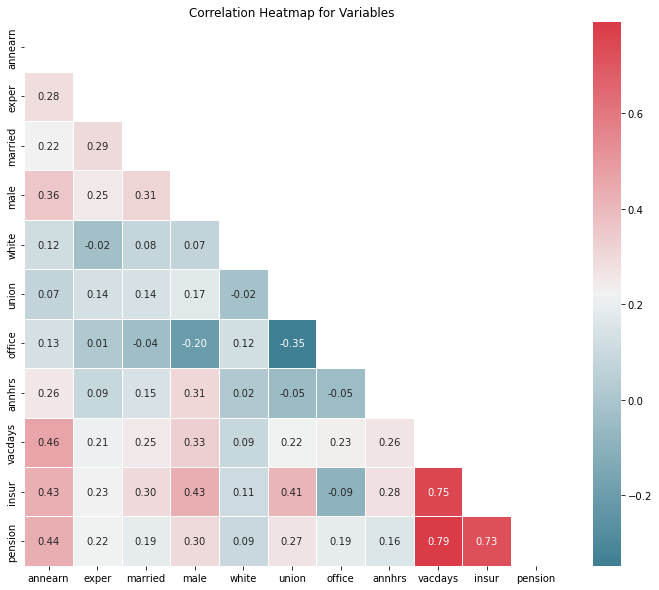

```python
# Correlation Plots
Corr = df_final.corr()

fig, ax = plt.subplots(figsize=(12,10))
colormap = sns.diverging_palette(220, 10, as_cmap = True)
dropvals = np.zeros_like(Corr)
dropvals[np.triu_indices_from(dropvals)] = True
sns.heatmap(Corr, cmap = colormap, linewidths = .5, annot = True, fmt = ".2f", mask = dropvals)
plt.title("Correlation Heatmap for Variables")
plt.show()
```

## Part 2b. Density Plots

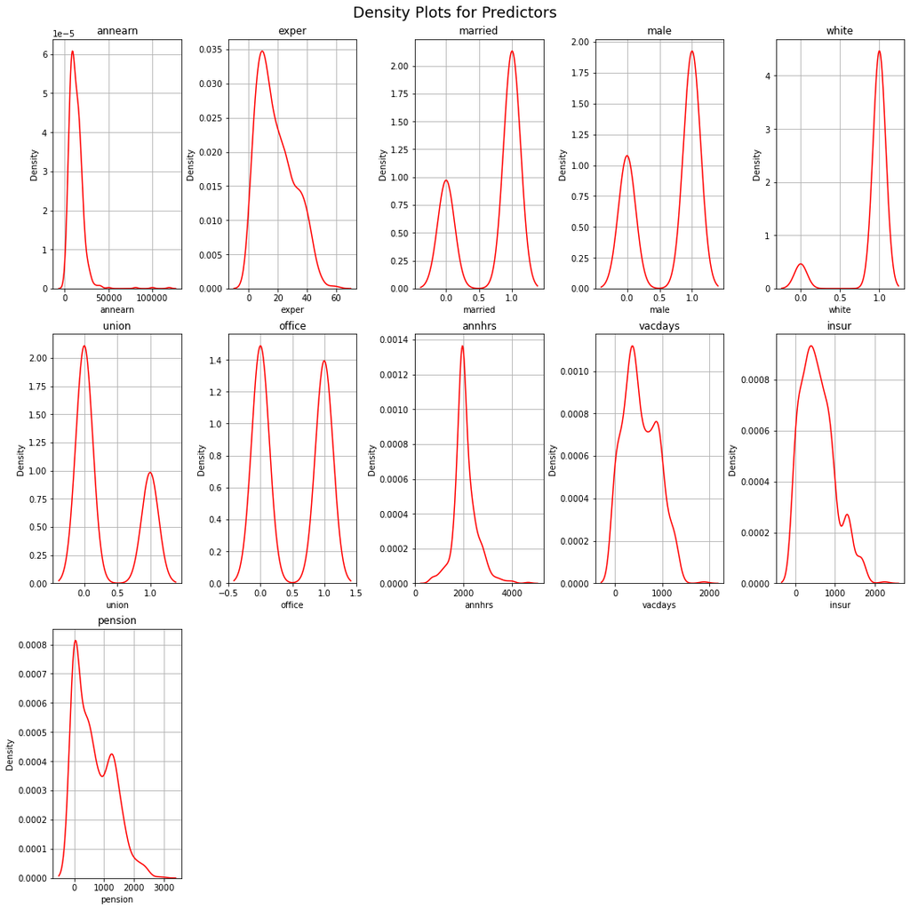

```python
# Density Plots
plt.figure(figsize=(15,15), constrained_layout=True)
plt.suptitle("Density Plots for Predictors", fontsize=18)
listname = ["annearn", "exper", "married", "male", "white", "union", "office", "annhrs",
         "vacdays", "insur", "pension"]

count = 1
for i in listname:
    plt.subplot(3, 5, count)
    sns.kdeplot(df_final[i], color = "red")
    plt.title(i)
    plt.grid()
    count += 1
plt.show()
```

## Part 2c & d. Non-Linearities and Outliers

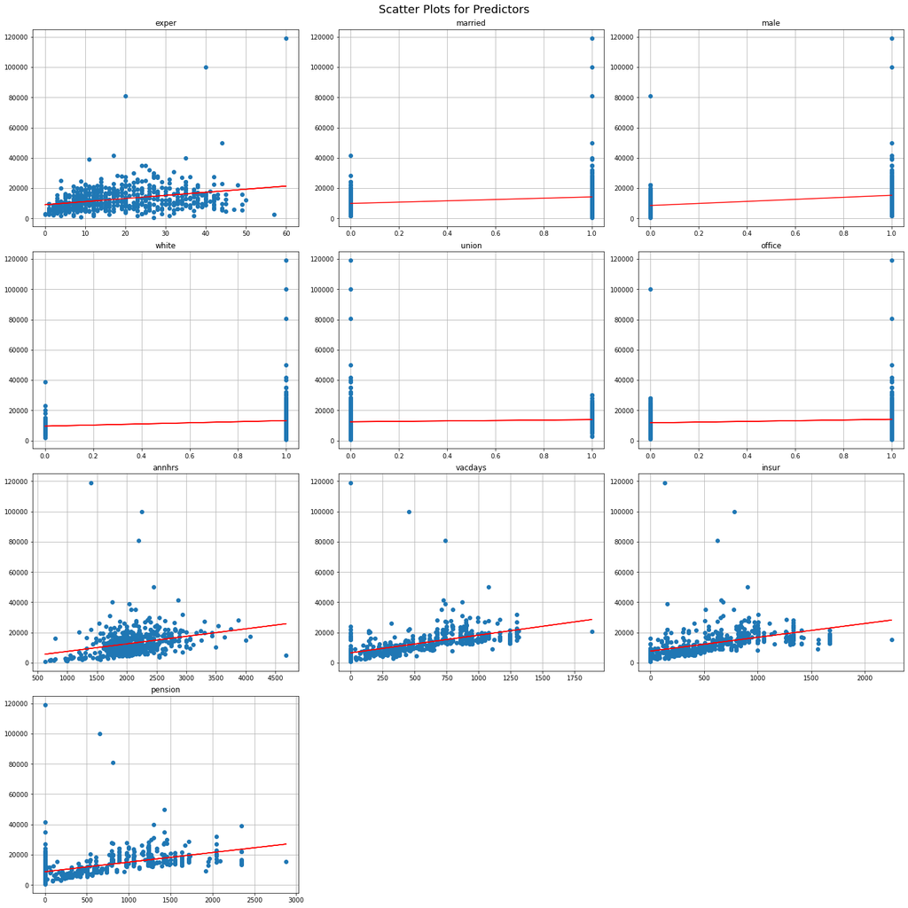

```python
# Scatter Plots
plt.figure(figsize=(20,20), constrained_layout=True)
plt.suptitle("Scatter Plots for Predictors", fontsize=18)
independent = ["exper", "married", "male", "white", "union", "office", "annhrs",
         "vacdays", "insur", "pension"]

count = 1
for i in independent:
    plt.subplot(4, 3, count)
    x = df_final[i]
    y = df_final['annearn']
    plt.plot(x, y, 'o')
    m, b = np.polyfit(x, y, 1)
    plt.plot(x, m*x+b, 'red')
    plt.title(i)
    plt.grid()
    count += 1
plt.show()
```

### Outliers and Unusual Observations

Generally speaking we see outlier observations at $annearn > 80,000$. These observations seem to have unusually high y values that does not follow a related trend in the x values. This is consistent across all variables. There does not seem to be many high leverage points with the exception of perhaps one observation at the far right end of our plots. Additionally, there seems to be one influential observation in our $exper$ variable scatter plot that has both a very high x value and a very high y value.

### Non-Linearities

Qualitatively there does not seem to be a lot of non-linearities in our quantitative variables. They seem to all generally follow a positive linear trend. $insur$ and $pension$ may exhibit some slight quadratic behavior since $annearn$ seems to decrease at very high values of $insur$ and $pension$. For these variables, it may make sense to include a quadratic term, but we would need to test this explicitly by including higher order terms in our regression and checking their significance.

If we included non-linear variables in the regression model without transformation, then we would get very poor fits to our model. We would be trying to fit a linear relationship on a variable that does not exhibit that behavior. Hence, the standard errors would be very high and the parameter estimates would likely be insignficantly different from 0.

## Part 2e. NaN Imputation

We have no missing observations so we do not need to do any imputation.

# Part 3. Model Building

In this section, we will explore several competing Ordinary Least Squares multiple regression models. In particular, our models will contain some combination of quantitative and indicator variables.

In our task to find the best overall model, we will begin with a base model and run it through our framework which consists of several different tests. Through this framework we will get a visual and quantitative assessment of our model and use that to iteratively build a better and better model, Hence, we will only delcare one model at the beginning of this section but will work through many models as we go through our analysis.

Ultimately, we will finalize our model and discuss the economic significance of our parameters and any inferences we can draw from our best model.

## Part 3. Model Declaration

As stated above, we will now declare our base model using the variables found in part 1 and explored in part 2.

The first model we will consider is:

$$ \begin{align*} annearn_i &= \beta_0 + \beta_1 exper_i + \beta_2 married_i + \beta_3 male_i + \beta_4 white_i + \\ &+ \beta_5 union_i + \beta_6 office_i + \beta_7 annhrs_i + \beta_8 vacdays_i + \beta_9 insur_i + \\ &+ \beta_{10} pension_i + \varepsilon_i \end{align*} $$

```python
# Base Model
mreg1 = smf.ols(formula = 'annearn ~ exper + married + male + white + union + office + \
    annhrs + vacdays + insur + pension', data = df_final).fit()
```

The estimated model is thus:

$$ \begin{align*} \underset{(se)}{\widehat{annearn}_i} &= \underset{(1783.45)}{-2095.84} + \underset{(26.47)}{104.81} exper_i + \underset{(720.53)}{508.38} married_i + \underset{(755.90)}{3346.35} male_i + \underset{(1058.64)}{1713.15} white_i + \\ &- \underset{(781.39)}{952.65} union_i + \underset{(761.30)}{1772.51} office_i + \underset{(0.72)}{1.93} annhrs_i + \underset{(1.65)}{3.53} vacdays_i + \underset{(1.37)}{2.18} insur_i + \\ &+ \underset{(0.87)}{1.97} pension_i \quad , \quad \textrm{Adj. } R^2 = 0.307 \end{align*} $$

We will now begin testing and working on this model to iteratively improve it and in the process compare it against competiting versions.

## Part 3. Multicolinearity

Firstly, we consider the case of multicolinearity. Recall from the scatterplot matrix that some of our variables were highly correlated with one another. This suggests that multicolinearity may be a problem. In order to test whether it is an issue, we check our VIFs.

```python
# VIF: Test for multicolinearity

# Extract matices using patsy
y, X = pt.dmatrices('annearn ~ exper + married + male + white + union + office + \
    annhrs + vacdays + insur + pension', data = df_final, return_type='dataframe')

# Get VIF
K = X.shape[1]
VIF = np.empty(K)
for i in range(K):
    VIF[i] = smo.variance_inflation_factor(X.values, i)
print(f'VIF: \n{VIF}\n')
```

```
VIF:
[34.81284916  1.16404462  1.2225158   1.43872083  1.04619889  1.44977341
  1.58419768  1.20921627  3.806212    3.62421663  3.16630345]
```

| Variable | VIF |
| --- | --- |
| exper | 1.16 |
| married | 1.22 |
| male | 1.44 |
| white | 1.05 |
| union | 1.45 |
| office | 1.58 |
| annhrs | 1.21 |
| vacdays | 3.81 |
| insur | 3.62 |
| pension | 3.17 |

In general, we use a cutoff of 4 or 10 for VIF scores. In our case, since our VIFs are below 10, we use the cutoff of 4. Yet even with this cutoff, none of our variable's VIF scores exceed 4. Hence, we can say that multicolinearity does not seem to be an issue

## Part 3. Heteroskedasticity

Next, we will examine our model to see if heteroskedasticity is an issue. Recall, if we have heteroskedasticity then one of the core assumptions of OLS will be violated and thus our parameters will not be BLUE.

To do this, we will impelement a Breusch-Pagan Test.

```python
# BP Test for Heteroskedasticity
## H_0: var = constant
name = ["Lagrange multiplier statistic", "p-value", "f-value", "f p-value"]
test = sms.het_breuschpagan(mreg1.resid, mreg1.model.exog)
print("BP Results:")
print(list(zip(name, test)))
```

```
BP Results:
[('Lagrange multiplier statistic', 25.293312760132256), ('p-value', 0.004816409140254677), ('f-value', 2.5905334323168376), ('f p-value', 0.004421885080568314)]
```

From our test, we get a p-value of 0.0048 which is less than 0.05. Because our BP test results in very low p-value, we conclude that variance is **not** constant and thus heteroskedasticity is an issue we will need to address.

To address this problem, we will first use robust standard errors.

```python
# Robust Standard Errors
mreg1_robust = smf.ols(formula = 'annearn ~ exper + married + male + white + union + office + \
    annhrs + vacdays + insur + pension', data = df_final).fit(cov_type = 'HC0')

#print(mreg1_robust.summary())

## pull out squared residuals
df_final_copy = df_final.copy()
df_final_copy["res2"] = mreg1_robust.resid**2

## Try to predict the squared residuals using a linear combination of our variables
mreg1_robus_aux = smf.ols('res2 ~ exper + married + male + white + union + office + \
    annhrs + vacdays + insur + pension', data=df_final_copy).fit()

## Get the regression f-statistic (f-test version)
f = mreg1_robus_aux.fvalue
fp = mreg1_robus_aux.f_pvalue

print("The F-Statistic for the Auxiliary Regression is: "+ str(f) +" and the P-Value is: "+ str(fp))

### We still have heteroskedasticity
```

```
The F-Statistic for the Auxiliary Regression is: 2.5905334323168376 and the P-Value is: 0.004421885080568314
```

Firstly, even with robust standard errors, a BP test (this time using the f-stat verison), still results in a very low p-value (0.0044) which means that our model still has issues of heteroskedasticity even with robust standard errors.

Additionally, robust standard errors seems to generally increase our standard errors to the point where many of our variables are no longer statistically significant.

We will now show our residual plots to get an idea as to which variable(s) might be causing heteroskedasticity within our model. This would allow us to try and use something like Weighted Least Squares or Genearlized Feasible Least Squares to remedy the issue.

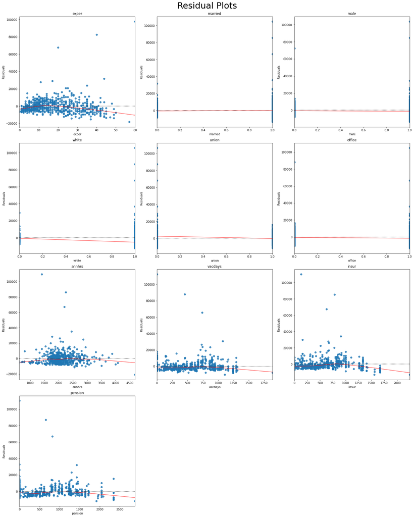

```python
# Residual Plots
plt.figure(figsize=(20,25), constrained_layout = True)

independent = ["exper", "married", "male", "white", "union", "office", "annhrs",
         "vacdays", "insur", "pension"]

count = 1
for i in independent:
    plt.subplot(4, 3, count)
    x = df_final[i]
    y = df_final['annearn']
    sns.residplot(x, y, data= df_final, lowess=True,
                                line_kws={'color': 'red', 'lw': 1, 'alpha': 1})
    plt.title(i)
    plt.ylabel("Residuals")
    plt.suptitle('Residual Plots', fontsize =30)
    count += 1
plt.show()
```

From the above plot, it seems that all of our quantitative variables might exhibit some heteroskedastic tendancies; however, $exper$ seems to have the greatest spread of variance with increasing x values. Hence, at least qualitatively, we suspect that $exper$ might be the culprit. However, for completeness's sake, we will implement Feasible Genearlized Least Squares which should serve to correct our issue of heteroskedasticity.

```python
# Generalized Least Squares
df_final_copy["ehatsq"] = mreg1.resid**2

# Estimate Weights
w_est = smf.ols('np.log(ehatsq) ~ exper + married + male + white + union + office + \
    annhrs + vacdays + insur + pension', data=df_final_copy).fit()

vari = np.exp(w_est.fittedvalues) # Estimated Variances
w = list(1/vari)

mreg1_fgls = smf.wls(formula = 'annearn ~ exper + married + male + white + union + office + \
    annhrs + vacdays + insur + pension', data = df_final_copy, weights = w).fit()

#print(mreg1_fgls.summary())

# Test for Heteroskedasticity
name = ["Lagrange multiplier statistic", "p-value", "f-value", "f p-value"]
test = sms.het_breuschpagan(mreg1_fgls.resid, mreg1_fgls.model.exog)
print("BP Results:")
print(list(zip(name, test)))
```

```
BP Results:
[('Lagrange multiplier statistic', 25.082252821919703), ('p-value', 0.005191758394566018), ('f-value', 2.5679991893505107), ('f p-value', 0.004778736421842558)]
```

Once again, implementing a BP test shows that heteroskedasticity is *still* an issue. The p-value for this BP test is 0.005 which is below our 5% level.

Thus, neither Robust standard errors nor FGLS were able to mitigate our heteroskedasticity issues. From the above residual plots, I hypothesize that the heteroskedasticity is due to the variable $exper$. I will test this by removing $exper$ from the model and re-testing for heteroskedasticity.

```python
# Model 2: Model Without Exper
mreg2 = smf.ols(formula = 'annearn ~ married + male + white + union + office + \
    annhrs + vacdays + insur + pension', data = df_final).fit()

## BP Test for Heteroskedasticity
### H_0: var = constant

name = ["Lagrange multiplier statistic", "p-value", "f-value", "f p-value"]
test = sms.het_breuschpagan(mreg2.resid, mreg2.model.exog)
print("BP Results:")
print(list(zip(name, test)))

## White Test for Heteroskedasticity
test2 = sms.het_white(mreg2.resid, mreg2.model.exog)
print("White Results:")
print(list(zip(name, test)))
```

```
BP Results:
[('Lagrange multiplier statistic', 9.308133517894968), ('p-value', 0.40933069923633003), ('f-value', 1.0330576219948104), ('f p-value', 0.41183428464178373)]
White Results:
[('Lagrange multiplier statistic', 9.308133517894968), ('p-value', 0.40933069923633003), ('f-value', 1.0330576219948104), ('f p-value', 0.41183428464178373)]
```

$$ \begin{align*} annearn_i &= \beta_0 + \beta_2 married_i + \beta_3 male_i + \beta_4 white_i + \\ &+ \beta_5 union_i + \beta_6 office_i + \beta_7 annhrs_i + \beta_8 vacdays_i + \beta_9 insur_i + \\ &+ \beta_{10} pension_i + \varepsilon_i \end{align*} $$

For now, we will leave our $\beta$ coefficients with their original indicies so as to not cause confusion in cross model comparisons.

## Part 3. Model Misspecification

Next, we will see if our model is correctly specified at order 1. To do this, we will conduct a Ramsey RESET test with power 2. If our RESET p-value is very low then that implies that our model should have higher order terms.

```python
# Ramsey RESET
RESET = dg.linear_reset(mreg2, power=2, test_type='fitted', use_f = True)

print("Ramsey-RESET:")
print(RESET)
```

```
Ramsey-RESET:
<F test: F=2.1129958535731483, p=0.14657166041125327, df_denom=605, df_num=1>
```

## Part 3. Outliers

In part 2, we qualitatively assessed that our data seems to have many unusual observations. In this section, we will quantitatively determine which of our variables are the most influential and might need to be removed.

To do this, we will utilize the idea of Cook's Distance and plot that value for observation against the index of the observation. Observations with high Cook's Distance (note: we are not strictly defining a cutoff but $4/n$ is standard) will be viewed as outlier.

Beyond this, we will also include an Influence Plot and an Influence Plot (from R).

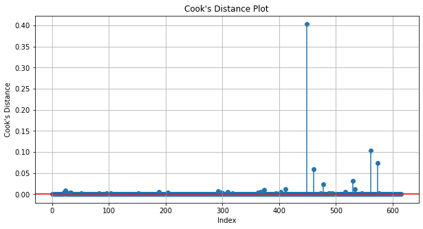

```python
# Cook's Distance

cooks2 = mreg2.get_influence().cooks_distance[0]

plt.figure(figsize=(10,5))
plt.scatter(df_final.index, cooks2)
plt.axhline(0, color = 'red')
plt.vlines(x = df_final.index, ymin = 0, ymax = cooks2)
plt.xlabel('Index')
plt.ylabel('Cook\'s Distance')
plt.title('Cook\'s Distance Plot')
plt.grid()
plt.show()
```

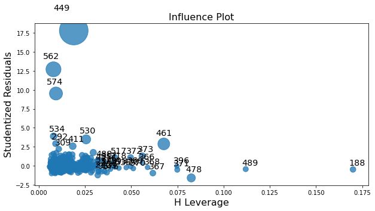

```python
# Influence Plot
fig, ax = plt.subplots(figsize=(10,5))
fig = sm.graphics.influence_plot(mreg2, ax = ax, criterion="cooks")
```

```python
# Influence Plot From R
import rpy2
import warnings
warnings.filterwarnings('ignore')

from rpy2.robjects import pandas2ri
import rpy2.rinterface as rinterface
pandas2ri.activate()

%load_ext rpy2.ipython
```

```
Unable to determine R home: [WinError 2] The system cannot find the file specified
```

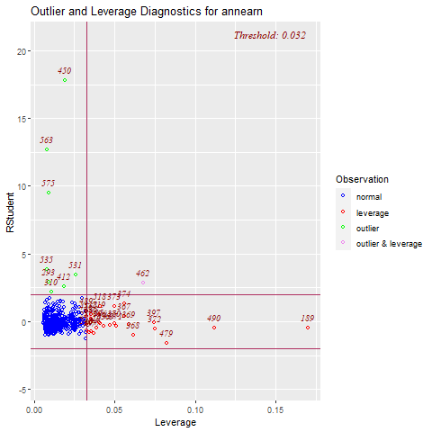

```python
%%R

library(olsrr)
library(wooldridge)

data('fringe')

mreg2.mod = lm(annearn ~ married + male + white + union + office + annhrs + vacdays + insur + pension, data = fringe)
ols_plot_resid_lev(mreg2.mod)
```

This last plot was generated using R code. In particular, it reveals that this model has many outlier and high leverage points, but that it does not have many ``influential'' observations (large in both x and y).

All of our plots serve to show us which observations would be considered unusual. In particular, there is agreement amongst all plots that:

- Outliers: 449, 562, 574
- Leverage: 188, 478, 489
- Influential: 461

We would consider dropping these observations in order to improve the fit of our model. We will not drop these observations yet; rather, we will wait until the end of our analysis to drop these observations and assess if they improve our model.

## Part 3. Evaluating Transformations

In this section, we will evaluate transformations to our variables. Notably, we will focus our attention on log transformatinos (log-linear, log-log, linear-log). Our scatterplots from part 2 might not obviously suggest the need for log transformations, but that behavior still seems like it could fit our variables.

We do not consider quadratic terms because RESET test indicated to us that we do not need higher order terms.

Additionally, we will not be applying a Box-Cox or Yeo-johnson transformation since our model is not intended to be a predictive model. It does not really make sense to predict annual earnings based on the variables in our model (vacation days, pension, hours worked, etc.); rather, our model is more useful for determining causality and examining relationships. In that sense, Box-Cox or Yeo-Johnson transformations wuold make our model hard to interpret.

Thus, instead, we will look at log transformations. Notably, we can only apply log transformations to our dependent variable and our independent variable $annhrs$ because all of our other predictors contain observations with 0s (which would break log transformations). Hence, the 4 models we look at are:

The non-transformed model (no $exper$) (M1):

$$ \begin{align*} annearn_i &= \beta_0 + \beta_2 married_i + \beta_3 male_i + \beta_4 white_i + \\ &+ \beta_5 union_i + \beta_6 office_i + \beta_7 annhrs_i + \beta_8 vacdays_i + \beta_9 insur_i + \\ &+ \beta_{10} pension_i + \varepsilon_i \end{align*} $$

The Log-Linear model (M2):

$$ \begin{align*} \ln(annearn_i) &= \beta_0 + \beta_2 married_i + \beta_3 male_i + \beta_4 white_i + \\ &+ \beta_5 union_i + \beta_6 office_i + \beta_7 annhrs_i + \beta_8 vacdays_i + \beta_9 insur_i + \\ &+ \beta_{10} pension_i + \varepsilon_i \end{align*} $$

The Log-Log Model (M3):

$$ \begin{align*} \ln(annearn_i) &= \beta_0 + \beta_2 married_i + \beta_3 male_i + \beta_4 white_i + \\ &+ \beta_5 union_i + \beta_6 office_i + \beta_7 \ln(annhrs_i) + \beta_8 vacdays_i + \beta_9 insur_i + \\ &+ \beta_{10} pension_i + \varepsilon_i \end{align*} $$

The Linear-Log Model (M4):

$$ \begin{align*} annearn_i &= \beta_0 + \beta_2 married_i + \beta_3 male_i + \beta_4 white_i + \\ &+ \beta_5 union_i + \beta_6 office_i + \beta_7 \ln(annhrs_i) + \beta_8 vacdays_i + \beta_9 insur_i + \\ &+ \beta_{10} pension_i + \varepsilon_i \end{align*} $$

```python
# Model Transformations

## Base Model
#print(mreg2.summary())

## Log Linear
mreg2_1 = smf.ols(formula = 'np.log(annearn) ~ married + male + white + union + office + \
    annhrs + vacdays + insur + pension', data = df_final).fit()
#print(mreg2_1.summary())

## Log Log
mreg2_2 = smf.ols(formula = 'np.log(annearn) ~ married + male + white + union + office + \
    np.log(annhrs) + vacdays + insur + pension', data = df_final).fit()
#print(mreg2_2.summary()) # cannot log vacdays, insur, or pension because they contain 0s

## This checks how many 0s a variable has
#count = (df_final['vacdays'] == 0).sum()
#print(count)

## Linear Log
mreg2_3 = smf.ols(formula = 'annearn ~ married + male + white + union + office + \
    np.log(annhrs) + vacdays + insur + pension', data = df_final).fit()
#print(mreg2_3.summary())

### Of these transformations the Log Log model seems to be the most appealing
# (highest R^2 & mostly sig parameters)
```

```python
# Report R Squared Values
RSquaredStore = np.zeros((4,1))
RSquaredStore[0,0] = mreg2.rsquared_adj
RSquaredStore[1,0] = mreg2_1.rsquared_adj
RSquaredStore[2,0] = mreg2_2.rsquared_adj
RSquaredStore[3,0] = mreg2_3.rsquared_adj
RSquaredStore
```

```
array([[0.29039856],
       [0.61922277],
       [0.64302447],
       [0.29123264]])
```

| Model | Adj. $R^2$ |
| --- | --- |
| M1 | 0.290 |
| M2 | 0.619 |
| M3 | 0.643 |
| M4 | 0.291 |

After running all 4 models, all of them have similar parameter significances. However, it appears that M3 (Log-Log) has the highest adjusted $R^2$ value with M2 (Log-Linear) coming second. However, notably, both of these models have nearly double the adjusetd $R^2$ value of the other two models. Thus, even though $R^2$ is an imperfect measure of model performance, we think that M2 and M3 will likely be the strongest models.

Furthermore, we will assess the transformations to our variables by using Quantile-Quantile plots.

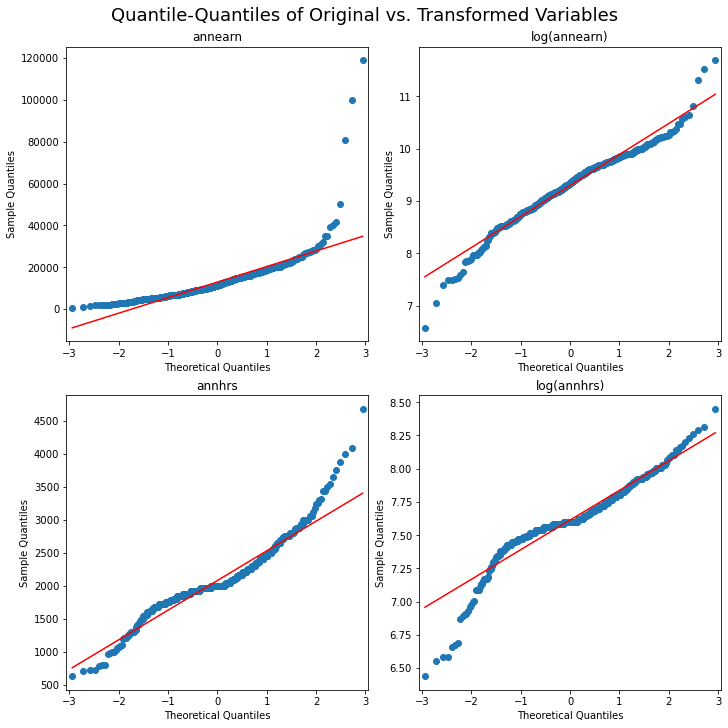

```python
# QQ Plots
fig, axes = plt.subplots(2, 2, figsize=(10,10), constrained_layout = True)
fig.suptitle("Quantile-Quantiles of Original vs. Transformed Variables", fontsize=18)

sm.qqplot(df_final["annearn"], line = 'r', ax = axes[0,0])
sm.qqplot(np.log(df_final["annearn"]), line = 'r', ax = axes[0,1])
sm.qqplot(df_final["annhrs"], line = 'r', ax = axes[1,0])
sm.qqplot(np.log(df_final["annhrs"]), line = 'r', ax = axes[1,1])

axes[0,0].set_title('annearn')
axes[0,1].set_title('log(annearn)')
axes[1,0].set_title('annhrs')
axes[1,1].set_title('log(annhrs)')

plt.show()
```

Ideally, we would want our observations to perfectly fit the line passing through the plots. This would indicate normality and make our variables work better within the context of linear regression. Our transformations, do largely help in this department. Although, for the sections of our plot that are improved there seem to be equivlent worsenings in the fit of the line. Hence, the QQ plot does not definitively reveal to us that our transformations were effective in normalization.

We now evaluate our transformed models by plotting Fitted Value and Residual Plots. In particular we want our fitted value plots to resemble roughly a linear 45 degree line (i.e., our observed values match our predicted values exactly on average). For our Residual Plots, we want a roughly even scatter around 0.

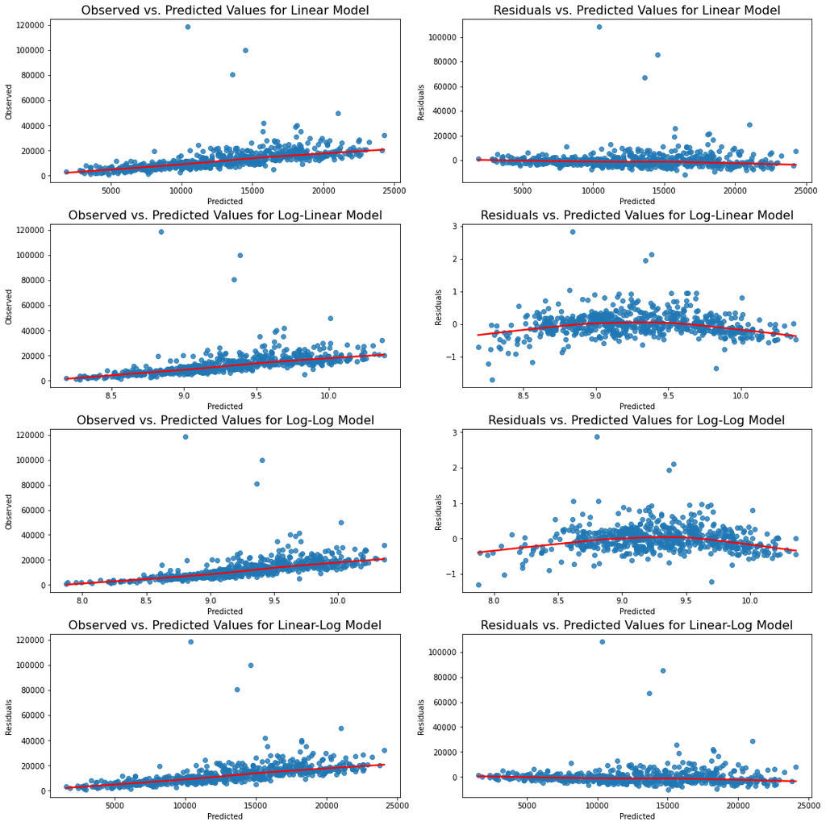

```python
# Fitted Value and Residual Plots for Models
fig, axes = plt.subplots(4, 2, figsize=(15,15), constrained_layout = True)

## Base Model
sns.regplot(x = mreg2.fittedvalues, y = df_final['annearn'], lowess=True, ax=axes[0,0],
            line_kws={'color': 'red'})
axes[0,0].set_title('Observed vs. Predicted Values for Linear Model', fontsize=16)
axes[0,0].set(xlabel='Predicted', ylabel='Observed')

sns.regplot(x = mreg2.fittedvalues, y = mreg2.resid, lowess=True, ax=axes[0,1],
            line_kws={'color': 'red'})
axes[0,1].set_title('Residuals vs. Predicted Values for Linear Model', fontsize=16)
axes[0,1].set(xlabel='Predicted', ylabel='Residuals')

## Log Linear Model
sns.regplot(x = mreg2_1.fittedvalues, y = df_final['annearn'], lowess=True, ax=axes[1,0],
            line_kws={'color': 'red'})
axes[1,0].set_title('Observed vs. Predicted Values for Log-Linear Model', fontsize=16)
axes[1,0].set(xlabel='Predicted', ylabel='Observed')

sns.regplot(x = mreg2_1.fittedvalues, y = mreg2_1.resid, lowess=True, ax=axes[1,1],
            line_kws={'color': 'red'})
axes[1,1].set_title('Residuals vs. Predicted Values for Log-Linear Model', fontsize=16)
axes[1,1].set(xlabel='Predicted', ylabel='Residuals')

## Log Log Model
sns.regplot(x = mreg2_2.fittedvalues, y = df_final['annearn'], lowess=True, ax=axes[2,0],
            line_kws={'color': 'red'})
axes[2,0].set_title('Observed vs. Predicted Values for Log-Log Model', fontsize=16)
axes[2,0].set(xlabel='Predicted', ylabel='Observed')

sns.regplot(x = mreg2_2.fittedvalues, y = mreg2_2.resid, lowess=True, ax=axes[2,1],
            line_kws={'color': 'red'})
axes[2,1].set_title('Residuals vs. Predicted Values for Log-Log Model', fontsize=16)
axes[2,1].set(xlabel='Predicted', ylabel='Residuals')

## Linear Log Model
sns.regplot(x = mreg2_3.fittedvalues, y = df_final['annearn'], lowess=True, ax=axes[3,0],
            line_kws={'color': 'red'})
axes[3,0].set_title('Observed vs. Predicted Values for Linear-Log Model', fontsize=16)
axes[3,0].set(xlabel='Predicted', ylabel='Residuals')

sns.regplot(x = mreg2_3.fittedvalues, y = mreg2_3.resid, lowess=True, ax=axes[3,1],
            line_kws={'color': 'red'})
axes[3,1].set_title('Residuals vs. Predicted Values for Linear-Log Model', fontsize=16)
axes[3,1].set(xlabel='Predicted', ylabel='Residuals')

plt.show()
```

The Fitted Value plots for all of our models seem to be pretty strong (i.e., the line seems to pass through the data effectively which implies a good predicition). However, it is in our residual plots that we see differences between our models. Notably, the residual plots for M1 and M4 look better on the surface due to the Lowess smoother line being more flat, but upon close inspection, it is clear that this is only the case due to the scale of the chart. Namely, M1 and M4 have a wide range of residuals. Thus, we actually say that M2 and M3 have better looking residual plots since the residuals more closely spread around 0.

Thus, from the above transformations, it seems that the log-log model is the most preferable. Notably, the $R^2$ is the highest, the fitted value plot looks strong (almost a straight line going through the data), and the residual plot looks to be fairly evenly spread around 0.

## Part 3. Interaction Terms

Of the variables in our model, the only interactions we suspect makes any economic sense is the combined effect of being a white male on annual earnings and the combined effect of being male and annual hours worked on annual earnings. Interactions between other terms do not appear to make economic sense, thus we will only consider 2 interaction terms:

White x Male:

$$ \begin{align*} \ln(annearn_i) &= \beta_0 + \beta_2 married_i + \beta_3 male_i + \beta_4 white_i + \\ &+ \beta_5 union_i + \beta_6 office_i + \beta_7 \ln(annhrs_i) + \beta_8 vacdays_i + \beta_9 insur_i + \\ &+ \beta_{10} pension_i + \delta_1 (male_i \times white_i) + \varepsilon_i \end{align*} $$

Male x ln(annhrs):

$$ \begin{align*} \ln(annearn_i) &= \beta_0 + \beta_2 married_i + \beta_3 male_i + \beta_4 white_i + \\ &+ \beta_5 union_i + \beta_6 office_i + \beta_7 \ln(annhrs_i) + \beta_8 vacdays_i + \beta_9 insur_i + \\ &+ \beta_{10} pension_i + \delta_2 (male_i \times \ln(annhrs_i)) + \varepsilon_i \end{align*} $$

```python
# Testing for Interaction Terms

## White Male
mreg3 = smf.ols(formula = 'np.log(annearn) ~ married + male + white + male:white + union + office + \
    np.log(annhrs) + vacdays + insur + pension', data = df_final).fit()
#print(mreg3.summary())

## Male annhrs
mreg3_1 = smf.ols(formula = 'np.log(annearn) ~ married + male + white + union + office + \
    np.log(annhrs) + male:np.log(annhrs) + vacdays + insur + pension', data = df_final).fit()
#print(mreg3_1.summary())
```

For first interaction term model, we get that our $\delta_1$ coefficient has a p-value of 0.1 which makes it insignificantly different from 0. Hence, this interaction term does not fit into our model.

For the second interaction term model, we get that our $\delta_2$ coefficient has a very small p-value and thus is statistically significant; however, its coefficient estimate is negative. This implies that the marginal effect of $\ln(annhrs)$ is:

$$\frac{\partial \ln(annearn)}{\partial \ln(annhrs)} = \beta_7 + \delta_2 male = 1.29 - 0.83 male$$

This implies that being male has a negative effect on the benefit of ln(annhrs) on our independent variable of ln(annearn). This seems to contradict the reasoning for including the interaction to begin with where we might think that men are disproportionately rewarded for extra work. Thus this contradiction leads us to believe that we should not include it in our model.

Thus, we move forward **not** including any interaction terms in our model. They are either insignificant or lack theoretical sense.

## Part 3. Model Selection (AIC and BIC)

Recall, that we stated that Adj. $R^2$ was not the single best method by which to evaluate models. Well, now we will introduce another metric by which to do this. AIC and BIC are critera such that lower scores imply better models. Thus, we assess our previous models (M1 - M4: not including interactions) on this basis.

```python
# AIC and BIC Values
AICBICStore = np.zeros((4,2))
AICBICStore[0,0] = mreg2.aic
AICBICStore[0,1] = mreg2.bic

AICBICStore[1,0] = mreg2_1.aic
AICBICStore[1,1] = mreg2_1.bic

AICBICStore[2,0] = mreg2_2.aic
AICBICStore[2,1] = mreg2_2.bic

AICBICStore[3,0] = mreg2_3.aic
AICBICStore[3,1] = mreg2_3.bic
AICBICStore
```

```
array([[12765.84466081, 12810.07713045],
       [  525.13795677,   569.37042641],
       [  485.37684253,   529.60931216],
       [12765.12018177, 12809.3526514 ]])
```

| Model | AIC | BIC |
| --- | --- | --- |
| M1 | 12765.85 | 12810.08 |
| M2 | 525.14 | 569.37 |
| M3 | 485.38 | 529.61 |
| M4 | 12765.12 | 12809.35 |

According to both AIC and BIC, the Log-Log model (M3) seems to be the best since it has the lowest score for both criteria. Hence, we will move forward with this model. We will resolve any remaining issues (like multicollinearity and outliers), bootstrap it, then test it with cross-validation.

## Part 3. Resolving Model Issues

### Multicollinearity

Although our VIF test did not indicate to us that multicollinearity is an issue with our model, we know that a few of our variables are highly correlated. Thus, we will see if the model improves when we drop some of these correlated variables.

Before we do this, we will first drop some variables that are statistically insignificant. Namely, these insignificant variables are the indicators: $married$, $union$, and $white$.

After this, we will drop $pension$ since (recall from the scatterplot from part (2) it has correlations of 0.79 and 0.73 with our other two predictors $vacdays$ and $insur$. We will then evaluate our model with these omissions.

Log-Log Model (reduced variable count) M5:

$$ \begin{align*} \ln(annearn_i) &= \beta_0 + \beta_3 male_i + \beta_6 office_i + \beta_7 \ln(annhrs_i) \\ &+ \beta_8 vacdays_i + \beta_9 insur_i + \varepsilon_i \end{align*} $$

```python
# Recall the Base Model
#print(mreg2_2.summary())

## Let us first drop married since it is insignificant
mreg4 = smf.ols(formula = 'np.log(annearn) ~ male + white + union + office + \
    np.log(annhrs) + vacdays + insur + pension', data = df_final).fit()
#print(mreg4.summary())

## Let us try dropping union and white now since they are also insignifcant
mreg4_1 = smf.ols(formula = 'np.log(annearn) ~ male + office + \
    np.log(annhrs) + vacdays + insur + pension', data = df_final).fit()
#print(mreg4_1.summary())

## Let us now try dropping pension since it is strongly correlated with insur and vacdays
mreg4_2 = smf.ols(formula = 'np.log(annearn) ~ male + office + \
    np.log(annhrs) + vacdays + insur', data = df_final).fit()
#print(mreg4_2.summary())
```

Dropping our insignificant variables did not do much to change the regression, but it did slightly change some of the coefficient estimates as well as tighten the standard errors slightly. More usefully, we are just removing bloat from the model.

After this, we removed $pension$ which was highly correlated with our other predictors. By doing this, we actually end up with a worse Adj. $R^2$ of 0.632 (compared to 0.643 of before) and worse AIC/BIC scores. This might indicate that we should keep $pension$ in the model; however, we believe it is too correlated with the other predictors and thus, it should be removed even if it worsens our model slightly.

In this sense, we have largely resolved our model's issues with multicolinearity.

### Unusual Observations

Recall from earlier that we had a handful of unusual observations. We will now see if our model improves when we drop these observations.

```python
# Create new dataframe without unusual observations
# NO stands for no outliers
df_finalNO = df_final.copy()
df_finalNO.drop([188,449,461,478,489,562,574], axis=0, inplace=True)
```

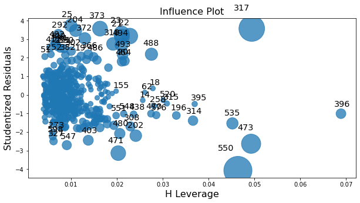

```python
# Regression without unusual observations
mreg5 = smf.ols(formula = 'np.log(annearn) ~ male + office + \
    np.log(annhrs) + vacdays + insur', data = df_finalNO).fit()
#print(mreg5.summary())

# Influence Plot
fig, ax = plt.subplots(figsize=(10,5))
fig = sm.graphics.influence_plot(mreg5, ax = ax, criterion="cooks")
```

| Model | Adj. $R^2$ | AIC | BIC |
| --- | --- | --- | --- |
| M5 (outliers) | 0.632 | 500.2 | 526.7 |
| M5 (outliers removed) | 0.696 | 334.3 | 360.8 |

By removing these outlier variabes, we dramatically improve the AIC and BIC values of our model, we improve the $R^2$ and we improve our coefficient estimates by reducing their standard errors.

We re-estimated the influence plot and of course, now there will be ``new'' unusual observations; however, these are much closer to the rest of the data relative to before. So perhaps we could continue to remove variables but since we only have about 600 observations, it is likely best to resist this temptation to keep removing observations.

Hence, we were correct in thinking that these unusual observations were harmful to our model performance. We will proceed with unusual observations being removed from our dataset.

As a quick sanity check, we will check our VIFs again with our new model (and with unusual observations removed)

```python
# Extract matices using patsy
y, X = pt.dmatrices('np.log(annearn) ~ male + office + \
    np.log(annhrs) + vacdays + insur', data = df_finalNO, return_type='dataframe')

# Get VIF
K = X.shape[1]
VIF = np.empty(K)
for i in range(K):
    VIF[i] = smo.variance_inflation_factor(X.values, i)
print(f'VIF: \n{VIF}\n') # It is still under 4, so multicollinearity shouldn't be an issue
```

```
VIF:
[1.25791948e+03 1.33524085e+00 1.37338812e+00 1.17735210e+00
 3.48027260e+00 3.30289633e+00]
```

By checking our VIFs, we once again see that multicolinearity should not be an issue for our model.

## Part 3. Bootstrapping

In this section, we will test the robustness of our coefficient estiamtes by bootstrapping our model. In other words, we will sample with replacement from our original data and run many regressions and plot histograms showing the distributions of our parameter estimates and adjusted $R^2$ values.

```python
# Bootstrapping
boot_slope1 = []
boot_slope2 = []
boot_slope3 = []
boot_slope4 = []
boot_slope5 = []
boot_interc = []
boot_adjR2 = []
n_boots = 100
n_points = df_finalNO.shape[0]
for i in range(n_boots):
 # sample the rows, same size, with replacement
    sample_df = df_finalNO.sample(n=n_points, replace=True)
 # fit a linear regression
    ols_model_temp = smf.ols(formula = 'np.log(annearn) ~ male + office + \
                              np.log(annhrs) + vacdays + insur', data = sample_df)
    results_temp = ols_model_temp.fit()

 # append coefficients
    boot_interc.append(results_temp.params[0])
    boot_slope1.append(results_temp.params[1])
    boot_slope2.append(results_temp.params[2])
    boot_slope3.append(results_temp.params[3])
    boot_slope4.append(results_temp.params[4])
    boot_slope5.append(results_temp.params[5])
    boot_adjR2.append(results_temp.rsquared_adj)
```

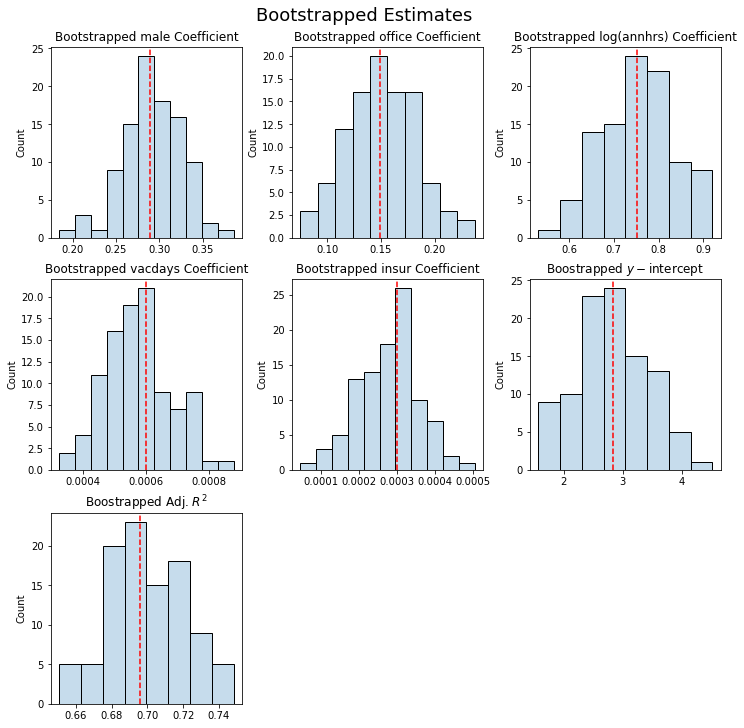

```python
# Bootstrapped Coefficients
fig, axes = plt.subplots(3,3, figsize=(10,10), constrained_layout = True)
fig.suptitle("Bootstrapped Estimates", fontsize = 18)

sns.histplot(boot_slope1, alpha = 0.25, ax=axes[0,0])
axes[0,0].axvline(x=0.2888, color='red', linestyle='--')
axes[0,0].set_title('Bootstrapped male Coefficient')

sns.histplot(boot_slope2, alpha = 0.25, ax=axes[0,1])
axes[0,1].axvline(x=0.1493, color='red', linestyle='--')
axes[0,1].set_title('Bootstrapped office Coefficient')

sns.histplot(boot_slope3, alpha = 0.25, ax=axes[0,2])
axes[0,2].axvline(x=0.7519, color='red', linestyle='--')
axes[0,2].set_title('Bootstrapped log(annhrs) Coefficient')

sns.histplot(boot_slope4, alpha = 0.25, ax=axes[1,0])
axes[1,0].axvline(x=0.0006, color='red', linestyle='--')
axes[1,0].set_title('Bootstrapped vacdays Coefficient')

sns.histplot(boot_slope5, alpha = 0.25, ax=axes[1,1])
axes[1,1].axvline(x=0.0003, color='red', linestyle='--')
axes[1,1].set_title('Bootstrapped insur Coefficient')

# Bootstrapped Y intercept
sns.histplot(boot_interc, alpha = 0.25, ax=axes[1,2])
axes[1,2].axvline(x=2.8311, color='red', linestyle='--')
axes[1,2].set_title('Boostrapped $y-$intercept')

sns.histplot(boot_adjR2, alpha = 0.25, ax=axes[2,0])
axes[2,0].axvline(x=0.696, color='red', linestyle='--')
axes[2,0].set_title('Boostrapped Adj. $R^2$')

fig.delaxes(axes[2,1])
fig.delaxes(axes[2,2])
plt.show()
```

It is clear from the above histograms that our model (M5) holds up well when bootstrapped. The red dashed line represents the value from the original regression and the histograms seem to indicate that these estimates holds up well across many iterations (i.e., the histograms are concentrated around these estimates). These reveals to us that our estimates is robust. Interestingly, our adjusted $R^2$ value ranmges from 0.66 to 0.74. This is range is slighly larger than what we might be comfortable with but the majority of our values fall between 0.68 and 0.72 which is a better range. Hence, we generally say that our model holds up well to bootstrapping.

## Part 3. Simple Out of Sample Performance and k-Fold Cross-Validation

Finally, to properly evaluate model performance, we will be implementing out of sample checks. This involves two similar but different procedures. Firstly, we will split our data into testing and training sets (70-30) and predict on the testing set. We will then record the Root Mean Squared Error (RMSE) as our measure of model performance. This naive check will then be compared against k-Fold Cross-Validation. In k-Fold, we essentially do the samething but more robustly by implementing 5 folds to our data. Below is code showing the process of splitting, training, and predicting with our models. The results will then be recorded into a summary table at the bottom.

```python
# Putting predictors into a dataframe for CV
df_predictorsNO= df_finalNO.copy()

df_predictorsNO = df_predictorsNO.drop(columns = ["annearn", "exper", "married", "white", "union", "pension"])
# ^ includes pension, just cut off
df_predictorsNO["annhrs"] = np.log(df_predictorsNO["annhrs"])
```

```python
# M5 model performance
x = df_predictorsNO
y = np.log(df_finalNO["annearn"])

# Perform an OLS fit using all the data
regr = LinearRegression()
model = regr.fit(x,y)
regr.coef_
regr.intercept_

# Simple Out of Sample Performance
## Split data into train (70%) / test (30%) samples:
x_train, x_test, y_train, y_test = train_test_split(x, y, test_size=0.3, random_state=0)

# Train the model:
regr = LinearRegression()
regr.fit(x_train, y_train)

# Make predictions based on the test sample
y_pred = regr.predict(x_test)

# Evaluate Performance
print('MAE:', metrics.mean_absolute_error(y_test, y_pred))
print('MSE:', metrics.mean_squared_error(y_test, y_pred))
print('RMSE:', np.sqrt(metrics.mean_squared_error(y_test, y_pred)))

# Perform a 5-fold CV
# Use MSE as the scoring function (there are other options as shown here:
# https://scikit-learn.org/stable/modules/model_evaluation.html

regr = linear_model.LinearRegression()
scores = cross_val_score(regr, x, y, cv=5, scoring='neg_root_mean_squared_error')
print('5-Fold CV RMSE Scores:', scores)
```

```
MAE: 0.22657252690527666
MSE: 0.08641994577562026
RMSE: 0.2939726956294075
5-Fold CV RMSE Scores: [-0.37289498 -0.24894724 -0.3721111  -0.34341417 -0.32554207]
```

```python
# Original Log - Log model performance (M3)
df_predictors = df_final.copy()
df_predictors = df_predictors.drop(columns = ["annearn"])
df_predictors["annhrs"] = np.log(df_predictors["annhrs"])

x = df_predictors
y = np.log(df_final["annearn"])

# Perform an OLS fit using all the data
regr = LinearRegression()
model = regr.fit(x,y)
regr.coef_
regr.intercept_

# Simple Out of Sample Performance
## Split data into train (70%) / test (30%) samples:
x_train, x_test, y_train, y_test = train_test_split(x, y, test_size=0.3, random_state=0)

# Train the model:
regr = LinearRegression()
regr.fit(x_train, y_train)

# Make predictions based on the test sample
y_pred = regr.predict(x_test)

# Evaluate Performance
print('MAE:', metrics.mean_absolute_error(y_test, y_pred))
print('MSE:', metrics.mean_squared_error(y_test, y_pred))
print('RMSE:', np.sqrt(metrics.mean_squared_error(y_test, y_pred)))

# Perform a 5-fold CV
# Use MSE as the scoring function (there are other options as shown here:
# https://scikit-learn.org/stable/modules/model_evaluation.html

regr = linear_model.LinearRegression()
scores = cross_val_score(regr, x, y, cv=5, scoring='neg_root_mean_squared_error')
print('5-Fold CV RMSE Scores:', scores)
```

```
MAE: 0.22263811824517007
MSE: 0.08560613889272374
RMSE: 0.2925852677301503
5-Fold CV RMSE Scores: [-0.35179169 -0.24420843 -0.35920929 -0.43334604 -0.41497894]
```

```python
# Original Model performance
df_predictors_og = df_final.copy()
df_predictors_og = df_predictors_og.drop(columns = ["annearn"])

x = df_predictors
y = df_final["annearn"]

# Perform an OLS fit using all the data
regr = LinearRegression()
model = regr.fit(x,y)
regr.coef_
regr.intercept_

# Simple Out of Sample Performance
## Split data into train (70%) / test (30%) samples:
x_train, x_test, y_train, y_test = train_test_split(x, y, test_size=0.3, random_state=0)

# Train the model:
regr = LinearRegression()
regr.fit(x_train, y_train)

# Make predictions based on the test sample
y_pred = regr.predict(x_test)

# Evaluate Performance
print('MAE:', metrics.mean_absolute_error(y_test, y_pred))
print('MSE:', metrics.mean_squared_error(y_test, y_pred))
print('RMSE:', np.sqrt(metrics.mean_squared_error(y_test, y_pred)))

# Perform a 5-fold CV
# Use MSE as the scoring function (there are other options as shown here:
# https://scikit-learn.org/stable/modules/model_evaluation.html

regr = linear_model.LinearRegression()
scores = cross_val_score(regr, x, y, cv=5, scoring='neg_root_mean_squared_error')
print('5-Fold CV RMSE Scores:', scores)
```

```
MAE: 3376.6220924769473
MSE: 21045985.71172306
RMSE: 4587.590403656702
5-Fold CV RMSE Scores: [ -4761.46688954  -3501.82480598  -4977.77802406 -10668.62897981
 -10851.24027937]
```

Below is a summary table showing the model number, the RMSE from the naive performance check, and the RMSE from 5-Fold Cross-Validation. Note that we want our RMSE values to be as close to 0 as possible (intuitively, we want our model to have small errors as smallers errors equates to a better model). So, in this table, we look for the model with the consistently smallest RMSE values.

[output not shown]

Firstly, we note the difference between the naive check and k-Fold. The naive check only checks one instance of our data while k-Fold checks several different groupings of our data and thus provides a far more robust estimate. From the values shown, the naive case generally falls within the range of k-Fold RMSE values; however, the naive case fails to properly show the fact that there is indeed a range. Hence, k-Fold is a more robust technique for evaluating model performance.

By looking at the table, we quickly see that our base model is by far the worst performing. This is largely due to the lack of log transformations in the original model. Beyond this, the comparisons between M5 and M3 are much more interesting. Using the naive out of sample check, it appears that M3 actually performs ever so slightly better than M5 (although the values are so close this may be negligble). However, when we look at our 5-fold Cross Validation, we see that they are comparable until we get to the last 2 folds where M5 definitively out performs M3. Using this metric, M5 seems to be our best performing model.

## Part 3. Marginal Effects

Our model (M5) does not contain any interaction or higher order terms, hence we do not have any relevant marginal effects to discuss.

## Part 3. Finalized Model

Based upon all of our previous work, we say that M5 is our best model:

$$ \begin{align*} \ln(annearn_i) &= \beta_0 + \beta_3 male_i + \beta_6 office_i + \beta_7 \ln(annhrs_i) \\ &+ \beta_8 vacdays_i + \beta_9 insur_i + \varepsilon_i \end{align*} $$

Additionally, M5 mostly satisfies the standard assumptions of a multiple variable OLS model in that it is linear in its $\beta$ values, its residuals are approximately clustered around 0, it does not exhibit heteroskedasticity, it does not seem to have endogeneity issues, and the predictors (except indicators) take a wide range of values. However, one assumption that we cannot be certain is fully satisfied is the multicolinearity assumption. Yes, our VIFs indicate to us that multicolinearity is not an issue, but there still exists moderate correlation between some of the predictors -- granted they are not perfectly correlated. Furthermore, the model has a Jarcque Bera statistic of 92.69 with probability 0, hence $\varepsilon$ is not normally distributed. This, however, is an optional assumption that does not need to be satisfied for OLS to work.

Therefore, we can reveal out final fitted model:

$$ \begin{align*} \underset{(se)}{\ln(\widehat{annearn}_i)} &= \underset{(0.455)}{2.831} + \underset{(0.031)}{0.289} male_i + \underset{(0.030)}{0.149} office_i + \underset{(0.061)}{0.752} \ln(annhrs_i) \\ &+ \underset{(0.000)}{0.0006} vacdays_i + \underset{(0.000)}{0.0003} insur_i + \varepsilon_i \quad , \quad \textrm{Adj. } R^2 = 0.696 \end{align*} $$

In particular, we interpret the model parameters as such:

- If our subject is male, we expect ln(annearn) to be 0.289 higher. In practical terms this means that the actual value of annearn will be $\exp(.289) \approx 1.34$ higher. Hence, if our subject is male, we expect annual earnings to increase by 33.5%.
- If our subject works in an office job, we expect ln(annearn) to be 0.149 higher. In practical terms, this means that the actual value of annearn will be $\exp(.149) \approx 1.16$ higher. Hence, if our subject works in an office job, we expect annual earnings to increasse by 16%.
- For a 1% increase in annual hours worked, we expect annual earnings to increase by 0.752%.
- For a \$1 increase in the value of vacation days, we expect annual earnings to increase by 0.06%.
- For a \$1 increase in the value of employee insurance, we expect annual earnings to increase by 0.03%.

In particular, the interpretation of our model parameters is slightly unusual because our model is a semilogarithmic equation; however, the interpretations are still far more palatable than if our model implemented non-standard transformations.

Additionally, our $\beta_0$ variable is not likely to be interpretable here since our model's dependent variable is logarithmic. This means that we are generally more interested in changes to the model rather than absolute values. In this sense, the y-intercept would not be very helpful. Additionally, it does not really make economic sense for someone to work 0 hours annually and still have positive earnings.

As far as economic insights, this model implies that being male has a strong positive effect on the expected annual earnings of an individual. Obviously, our model does not speak as to the root cause of this difference rather that there is a difference in expected annual earnings. Additionally, but not surprisingly, the model implies that being an office worker is likely to improve your annual earnings over not being an office worker. Furthermore, we can infer that the more an individual works, the more we expect their annual earnings to increase.

It is important to note that we might expect a variable like annual earnings to have a diminishing effect; however, our model does not have the higher order terms necessary to model this effect. We chose to not include higher order terms because the Ramsey RESET test deemed it unnecessary. In the appendix, we will very briefly touch on what a model with quadratic terms could have looked like.

# Appendix

Here we will include a few additional pieces of analysis that were not critical to the main report but that are interesting nevertheless.

### Conditional Expectations and Residual Plots

In this brief section, we will provide the CERES plots for our 3 quantitative predictors in M5.

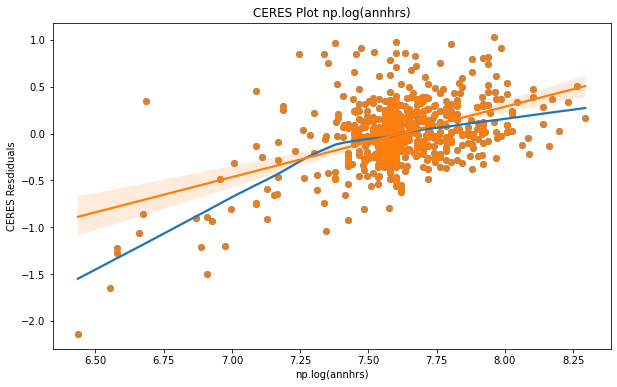

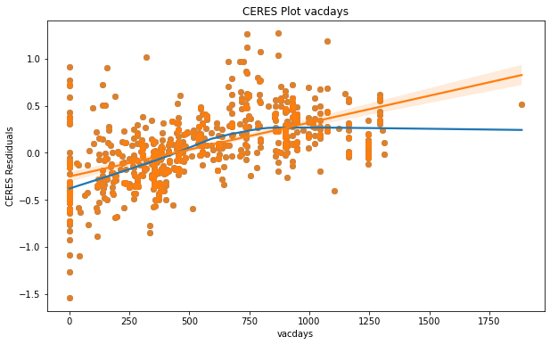

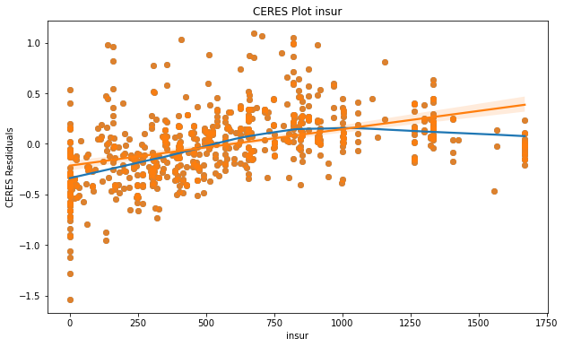

```python
from statsmodels.graphics.regressionplots import plot_ceres_residuals

def ceres_plot(model, data, variable):

    # produce plot
    plot_ceres_residuals(model, variable)
    ax = plt.gca()

    # don't show plot in notebook
    plt.close()

    # Pull datapoints from scatterplot from the statsmodels plot
    line = ax.lines[0]
    X = line.get_xdata()
    Y = line.get_ydata()

    # Store the results into format that works with seaborn
    df = pd.DataFrame(np.array([X,Y]).T, columns = [variable, "CERES Resdiduals"])
    plt.figure(figsize = (10, 6))

    # plot the results in a way similar to R
    sns.regplot(x = variable, y = "CERES Resdiduals", data =df, lowess = True)
    sns.regplot(x = variable, y = "CERES Resdiduals", data =df)

    plt.title("CERES Plot "+variable)

ceres_plot(mreg5, df_finalNO, 'np.log(annhrs)')
ceres_plot(mreg5, df_finalNO, 'vacdays')
ceres_plot(mreg5, df_finalNO, 'insur')
```

These plots suggest that our model might not be such a great predictor at low values of log(annhrs) or high values of vacdays and insur. We can try to look at higher order terms even though our Ramsey RESET test said they were not necessary.

### Higher Order Terms

Our CERES plots seem to imply that our model could improve with the inclusion of higher order terms. Hence we will briefly explore this. First, we will add in every quadratic term we can to see how that affects our model.

```python
# Let us define our new model
mreg_kiwi = smf.ols(formula = 'np.log(annearn) ~ male + office + \
    annhrs + I(annhrs**2) + vacdays + I(vacdays**2) + insur + I(insur**2)', data = df_finalNO).fit()
#print(mreg_kiwi.summary()) # a high R^2 and low AIC/BIC.

# Do we need more higher order terms?
RESET_kiwi = dg.linear_reset(mreg_kiwi, power=2, test_type='fitted', use_f = True)
print(RESET_kiwi)

# skeptical of the RESET results... All quantitative variables are now order 2, yet
# the test implies we need more second order terms.
```

```
<F test: F=34.0524910011983, p=8.788842035518665e-09, df_denom=599, df_num=1>
```

When including quadratic terms for every variable (even though $vacdays^2$ is insignificant), we find that the adjusted $R^2$ increases to 0.730 and the AIC/BIC values both decrease. This seems to imply that our model has improved with the addition of these quadratic terms. Although, it is important to note that the coefficients for these quadratic terms are extraordinarily small (essentially 0).

Interestingly, the Ramsey RESET test, in this case, has a p-value of nearly 0 which implies that we need more second order terms. So we can add in the interaction term from earlier in the analysis.

```python
# Perhaps, we try adding interactions and seeing what happens now

mreg_strawberry = smf.ols(formula = 'np.log(annearn) ~ male + office + \
    annhrs + I(annhrs**2) + male:annhrs + vacdays + I(vacdays**2) + insur + I(insur**2)',
            data = df_finalNO).fit()
#print(mreg_strawberry.summary())

RESET_strawberry = dg.linear_reset(mreg_strawberry, power=2, test_type='fitted', use_f = True)
print(RESET_strawberry) # The test still says we need more 2nd order terms...
# There are no other economically sensible interactions to add
# Perhaps we cannot put as much value into the RESET test
```

```
<F test: F=22.58028958560054, p=2.526889009863131e-06, df_denom=598, df_num=1>
```

The inclusion of the interaction term does not affect our model performance very much and it, itself, is not very impactful (just like before). However, upon running the Ramsey RESET test again, we still get a significantly small p-value which implies we need even more second order terms. This is a curious puzzle becauae we have included all of the economically sensible second order terms that we can. This casts some doubt on how important one should consider the RESET test to be.